# Scientific virtues

Rob Davies

## We are learning how to think critically for ourselves

*Active learning* works best even if it sometimes feel challenging

- Active learning is what you do when you ask or answer questions
- We will prompt you sometimes with Activate

**Activate**

What makes [your] science good or credible?

## Our plan

**What we can do**

1. An era of crises
2. Reform, revolution, and renaissance
3. Critical reflections
4. Second thoughts
5. Embrace variation, accept uncertainty, seek diversity

## Science reform language co-opted

- MAGA and “Gold standard science” (Delawalla et al., 2025)
  - Executive Order 14303 (Trump, 2025) mimics the language of the reform movement
  - But appears to enable political appointees to designate research as scientific misconduct

[figure not shown]

Trump (2025): The Trump “Gold standard” executive order

## The Protzko paper retraction

- Study appearing to show benefits of rigour-enhancing practices (Protzko et al., 2024):
  - confirmatory tests, large sample sizes, preregistration and methodological transparency
- Retracted after it is found that authors had not, in fact, engaged in rigour-enhancing practices (Bak-Coleman & Devezer, 2024; Hullman, 2024a, 2024b)

[figure not shown]

The retracted Protzko et al. (2024) paper

## The stages of revolution

- How did we get here?
- Gelman (2016) presents a brilliant account of the rolling series of events that led to calls for reform in the early 2000s

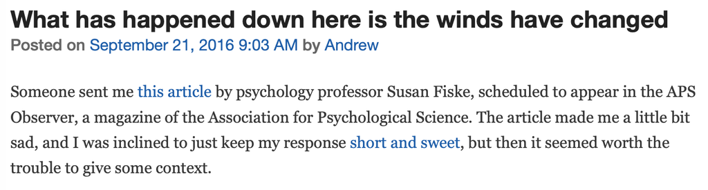

Gelman (2016): “Then, all of a sudden, the world turned upside down”

## Voodoo correlations

Vul et al. (2009) identified a puzzle:

- Measures of personality and emotion seldom have reliabilities greater than .8
- Neuroimaging measures seem typically to be reliable at .7 or less
- Yet reported correlations exceed the upper bound set by these reliabilities

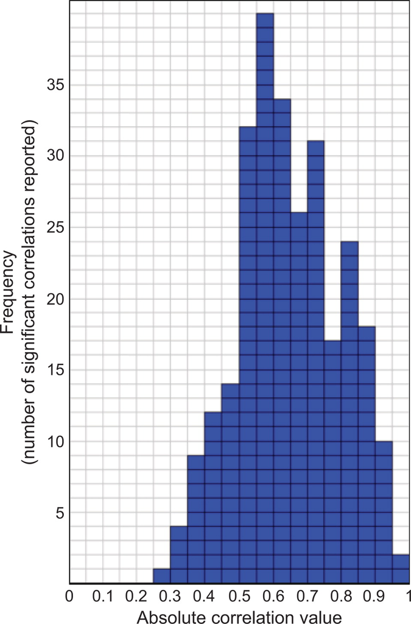

Vul et al. (2009): Impossibly high correlations derive from defective methods

## The crisis special issue

- In a special issue of the journal *Perspectives in Psychological Science*, we see the outline of the replication crisis emerging
- Pashler & Harris (2012) address the arguments against there being a crisis at the time

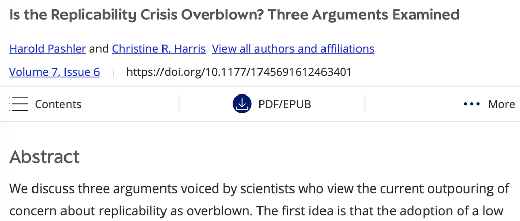

Pashler & Harris (2012): The crisis special issue

## Most research findings are false

- Ioannidis (2005; though see Goodman & Greenland, 2007) argued that:
  - Probability that a research claim is true depends on:
    - study power and bias
    - number of other studies on the same question
    - ratio of true to no relationships among the relationships probed in a field
  - In fields comprising smaller studies of smaller effects, flexibility in methods, and multiple teams involved in a chase for significance
  - Simulations show it is more likely for a research claim to be false than true

[figure not shown]

Ioannidis (2005): Most findings are wrong

## False positive psychology and undisclosed flexibility

- Simmons et al. (2011) demonstrate that exercising flexibility around decision-making at various points *researcher degrees of freedom*:
  - Should more data be collected?
  - Should some observations be excluded?
  - Which conditions should be combined and which ones compared?
  - Which control variables should be considered?
  - Should specific measures be combined or transformed or both?
- Can easily result in the production of false positive discoveries

[figure not shown]

Simmons et al. (2011): False positive psychology and undisclosed flexibility

## Apparent low rate of replication attempts

- Makel et al. (2012; but see Rakow, 2026) reported that
  - corrective mechanisms like scientists attempting replications
  - turned out to be rare in the psychology literature (about $\sim 1.5%$)

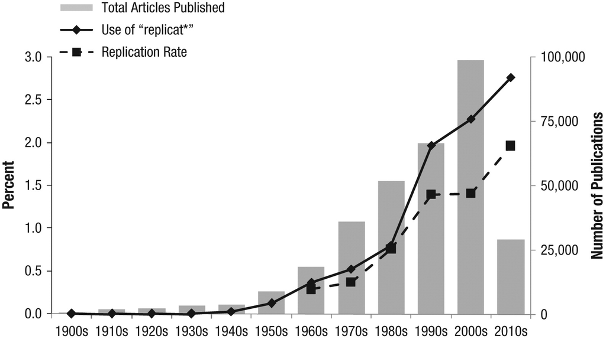

Makel et al. (2012): Apparent low rate of replication attempts

## Low rate of successful replications

- Large-scale attempts to replicate multiple studies at once (e.g., Open Science Collaboration, 2015)
  - Appeared to show that for substantial numbers of studies
  - Results could not be reproduced in replication studies:
    - Original significant results not significant
    - Effect sizes smaller

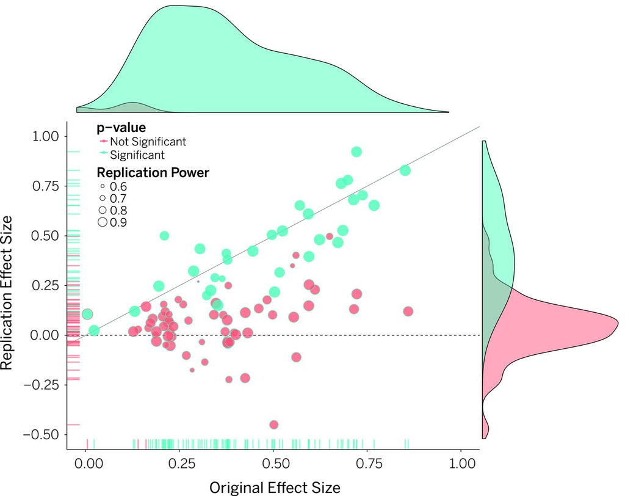

Open Science Collaboration (2015): Apparent low rate of successful replications

## Low power studies common

- Button et al. (2013) estimated the median statistical power of studies in the neurosciences to be between $\sim 8\%, \sim 31\%$
  - Low power if samples are small, or if effect sizes are small, or both
- Argued that low power will mean that effects will be exaggerated and results will be less likely to be reproducible

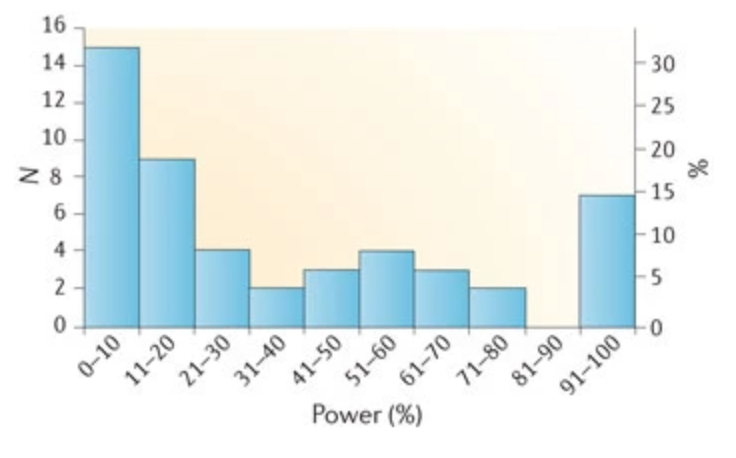

Button et al. (2013): Histogram of median study power calculated for each of the n = 49 meta-analyses

## Questionable Research Practices

John et al. (2012; see also Nagy et al., 2025) reported surprisingly high prevalence of Questionable Research Practices (QRPs) e.g.:

- Failing to report all of a study’s dependent measures
- Deciding whether to collect more data after checking whether the results were significant
- Reporting an unexpected finding as having been predicted from the start
- Selectively reporting studies that “worked”
- QRPs could explain significant effects despite prevalence of low power

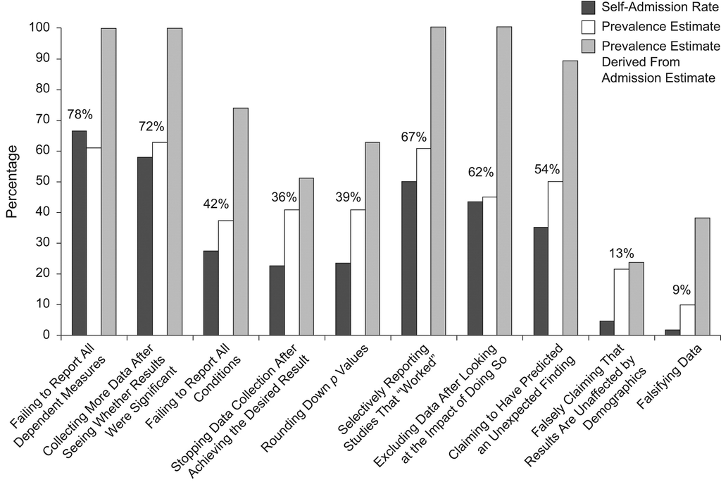

John et al. (2012): QRP self-admission, prevalence estimate

## Forking paths

(Gelman & Loken, n.d., 2017; Gelman & Loken) borrow from Borges to describe the *garden of forking paths*

- Researchers may perform a reasonable analysis given their assumptions and data
- But would have performed other analyses in other circumstances
- Exercising flexibility over decision-making without intending to

[figure not shown]

Figure 1: Gelman & Loken (2017): a garden of forking paths; one path taken among many possible

## Meehl warned us

Many of the concerns were raised by Paul Meehl over a series of papers (e.g., Meehl, 1967, 1969; Meehl, 1990; Meehl, 1978)

- But then ignored in subsequent practice

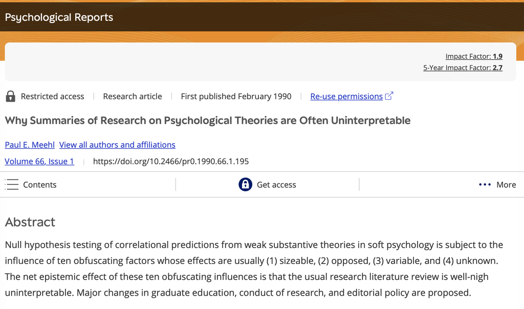

Meehl (1990): warned us

## Activate

Our learning questions then are these:

**Activate**

- Do you recognize the problems that were identified in the reports you read?
- Do you recognize these problems in the work you see now?

## The reform response

**The reasons**

- We will identify the response associated with the problems identified in the 2000s (Gelman & Vazire, 2021)
  - Manifestos, guidelines, revolutions, renaissance
    - The *Open Science* movement

## Organizations, groups, infrastructure and actors

- Society for the Improvement of Psychological Science (SIPS): conferences, hackathons
- Framework for Open and Reproducible Research Training (FORRT): teaching resources, glossaries
- ReproducibiliTea: A network of local journal clubs, often early-career-led
- PsyArXiv/OSF Preprints community
- Center for Open Science (COS): Runs the Open Science Framework (OSF)
- UK Reproducibility Network (UKRN)
- Psychological Science Accelerator (PSA), ManyBabies, Many Labs
- PubPeer
- Retraction Watch

## Manifestos

Munafò et al. (2017) identify:

- The need to improve the reliability and efficiency of scientific research
- Argue for the adoption of measures to improve the scientific process
- Against threats to reproducible science
- From our tendencies to bias and self-deception

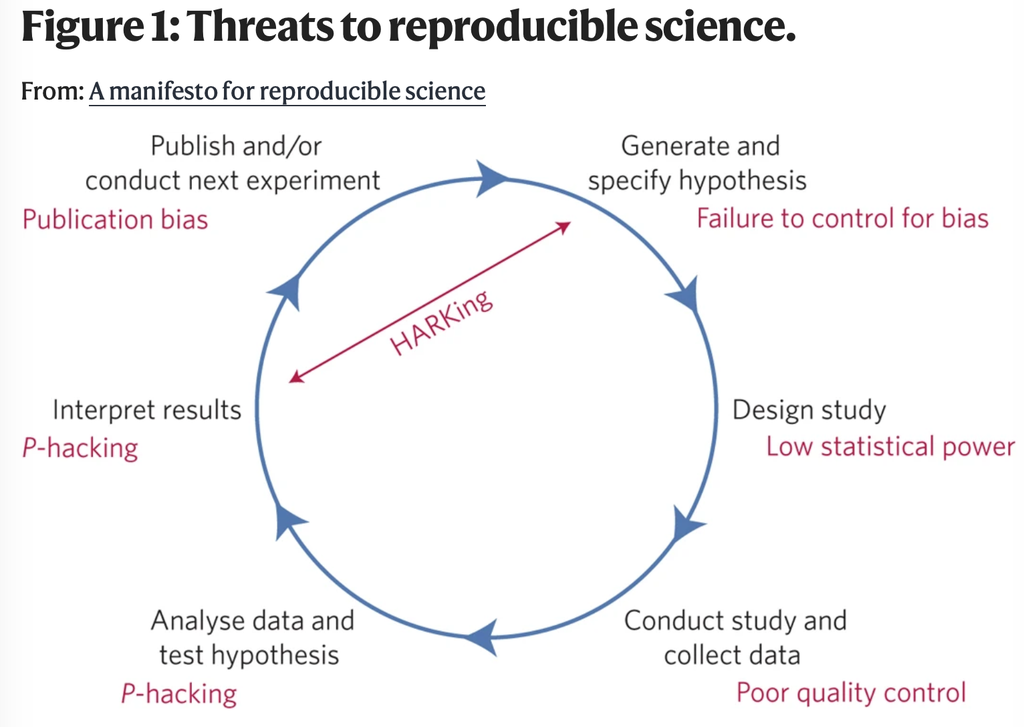

Munafò et al. (2017): The manifesto is a response to these threats

## Guidelines and standards

Transparency and Openness Promotion (TOP) (Nosek et al., 2015): standards to move scientific communication toward greater openness

- Transparency, sharing, transparency around data, analysis
- Preregistration of studies and analysis plans
- Encouraging replication

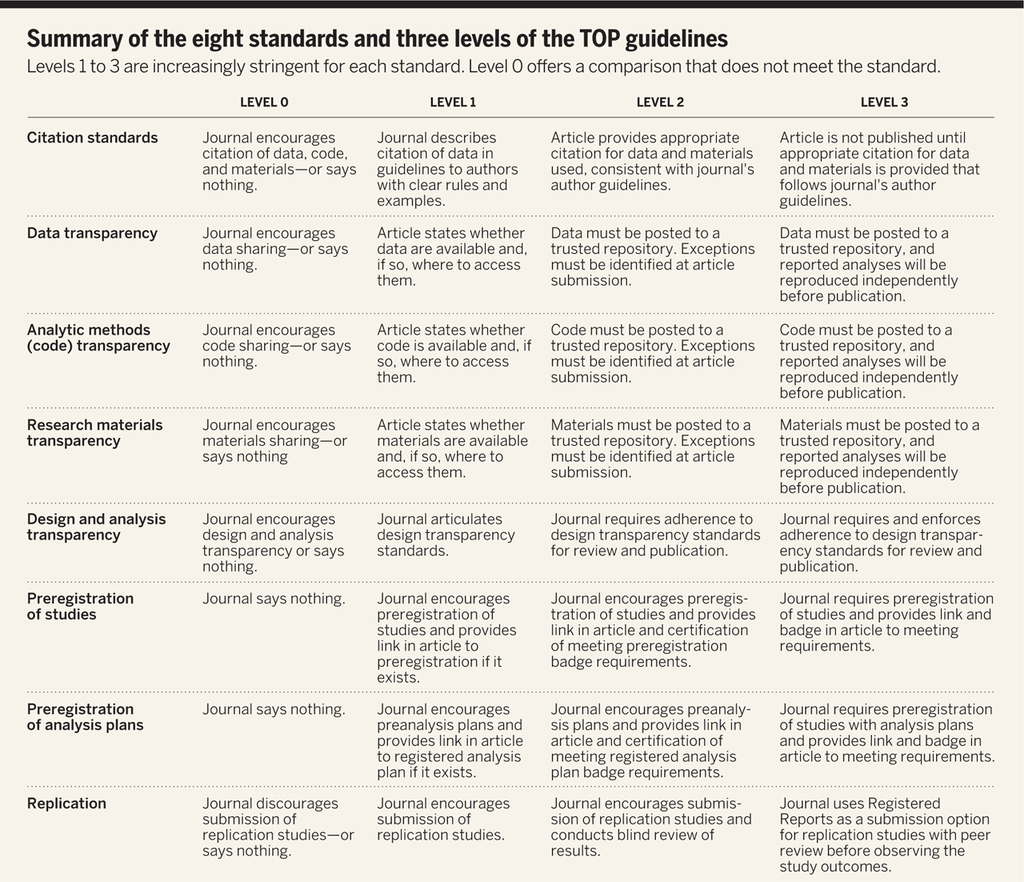

Nosek et al. (2015): Promoting an open research culture, the TOP guidelines

## A revolution, a renaissance

Through the later 2010s, we see reports about widespread changes in practice (Nelson et al., 2018; Nosek et al., 2018; Nosek et al., 2022; Vazire, 2018)

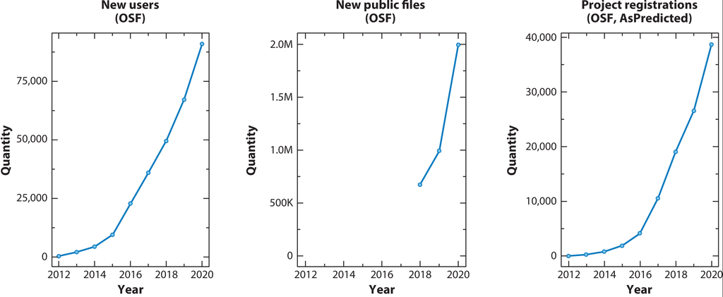

Nosek et al. (2022): Dramatic increases in the volume of openness, data sharing, and registration over time

## Activate

Our learning questions then are these:

**Activate**

- Do you recognize the organizations, the standards, the actors?
- Do you have any questions about impacts or effectiveness?

## Unpicking all of this

We can begin now to unpick all of this, in the process of developing our own critical position

**The reasons**

- We will look at Open Science as a narrative and as a social movement
- We will start to reflect on the work that has been done, and that we need to do

## Open Science as a narrative

Bartscherer (2026): the Open Science story is “purposeful, influential, and by no means neutral”

- Open science: the good (slow, equitable, inclusive, sustainable) science
- Counters the corrupting impacts of peverse incentives or human flaws to save our science and thus public faith in science
- Through changes in practice

[figure not shown]

Bartscherer (2026): The narrative side of (Open) Science

## Open Science as a social movement

Peterson & Panofsky (2023) argue that the reproducibility crisis has had a substantial and lasting impact because of the efforts of a group of scientific activists: *metascientists*

- There have been crises before but *metascience* stitched together specific problems into a transparency narrative
  - Concerned with the forms of science: how it is practiced, recorded, stored, and shared
  - Offering diagnoses located in findings about replication failures, false positives, QRPs
  - Rooted in a psychology of scientists that emphasises the biases
  - Offering solutions that supposedly apply everywhere in science

[figure not shown]

Peterson & Panofsky (2023): metascience as a scientific social movement

## Open Science as a social movement

Peterson & Panofsky (2023) argue that the *metascience* ideas

- Were disseminated by science journalists
- Were shared through social media
- Were associated with the actions of moral entrepreneurs who sought to establish and enforce rules
- Hybridized with older ideas about open access, free software
- Drew on underpinning critiques from Jacob Cohen and Paul Meehl
- Benefitted from funding from private foundations
- Took on ideas and structures from contemporary technology (platforms, efficiency, frictionlessness, data-based evaluations)

[figure not shown]

Peterson & Panofsky (2023): metascience as a scientific social movement

## Arnold funding and its influence

Lockhart (2026) identifies key funders:

- The Arnold Foundation gave 80 million dollars 2012-17:
  - to Nosek to create the Center for Open Science (COS)
  - to Ioannidis to build the Meta-Research Innovation Center
  - to Retraction Watch
- Corporate influence does not have to direct work to drive the direction of science (Bak-Coleman et al., 2026)

## Bropenscience

Whitaker & Guest (2020):

- Within the open science movement a bro will often be condescending, forthright, aggressive, overpowering, and lacking kindness and self-awareness
- They often veer into antisocial patterns of dialogue, such as sealioning
- Homogeneous groups of people preferentially hiring and promoting others like themselves

[figure not shown]

Whitaker & Guest (2020): #bropenscience is broken science

## Bropenscience

Whitaker & Guest (2020): What can you do? Recommend the Mozilla Open Leadership Framework as a good place to start

- Understanding: You make the work accessible and clear
- Sharing: You make the work easy to adapt, reproduce, and spread
- Participation & inclusion: You build shared ownership and agency with contributors through accountability, equity, and transparency
- Listen to the people who are not usually heard
- The true revolution lies in empowering the historically disempowered

[figure not shown]

Whitaker & Guest (2020): #bropenscience is broken science

## Questionable metascience practices

Rubin (2024) identifies:

- Rejecting or ignoring self-criticism
- A fast ‘n’ bropen scientific criticism style
- Overplaying the role of replication in science
- Assuming a replication rate is “too low” without specifying an “acceptable”” rate
- An unacknowledged metabias towards explaining the replication crisis in terms of researcher bias
- Assuming that researcher bias can be reduced
- Devaluing exploratory results as being more “tentative” than confirmatory results
- Presuming that questionable research practices are problematic research practices
- Focusing on knowledge accumulation
- Focusing on specific scientific methods

## Activate

Our learning questions then are these:

**Activate**

- When, why, and how can we do and support work
  - That is an adequate response to the problems or questions
  - That is not “bro-y”
  - And that actively helps to empower the historically disempowered

## Unpicking all this: critical reflections

We draw on recent thinking or observations to reflect on key practice recommendations

**The reasons**

- What makes science open or good?
  - Replication
  - Preregistration
  - Data or analysis code sharing
  - Automated robustness checks
- We consider critically the utility or helpfulness of seeking or finding the presence of these features in science

## Replications were more frequent and varied than was realized

- Makel et al. (2012)’s report that few replication studies have been published was influential but Rakow (2026) showed that
  - The Makel et al. (2012) analysis underestimated the presence of replications in the literature
  - Replication rates appear to vary greatly between research fields

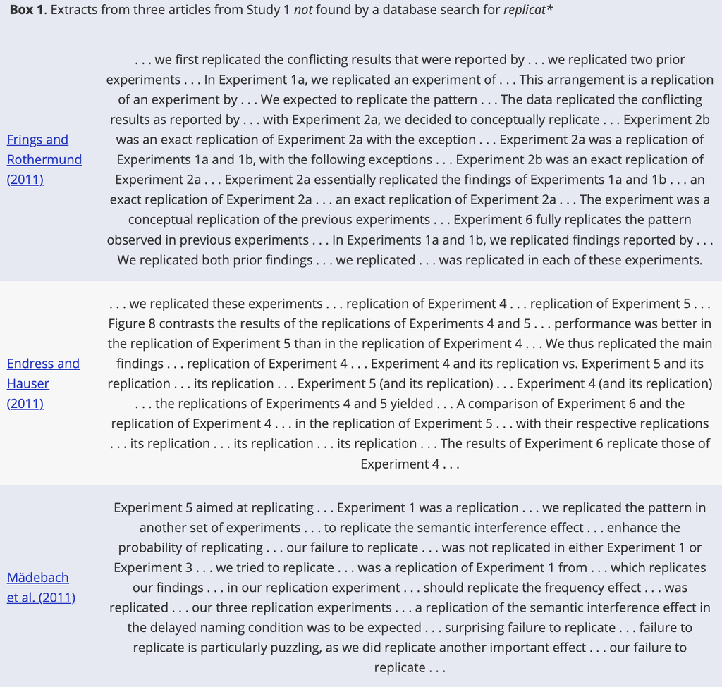

Rakow (2026): The language of replication

## Replications were more frequent and varied than was realized

- Database searches have important limitations
  - About 90% of articles that discuss replication and over 80% of articles with author-identified replications are missed by searching databases for keywords like `replicat*`
  - because databases hold few details per article
- Between-field differences in the prevalence of experimental designs or the prevalence of multistudy articles contribute to variation in the occurrence of replications

## What does replication mean?

- Different *kinds* of replication study can be identified, each providing different kinds of information (Rakow, 2026):
  - Replication: verify a finding by repeating a procedure (Schmidt, 2009)
    - direct or literal: duplications of sampling, environment, manipulations, measurements, and analyses
    - direct or operational: duplications of sampling and measurement procedures as described in reports
    - conceptual or extension: using different methods to test a finding through variation or extension

**Readings**

Interesting discussions of kinds of replication and their uses can be found in Hüffmeier et al. (2016), Lykken (1968), Schmidt (2009) and Zwaan et al. (2018)

## What does replication tell us about the truth of claims?

- Devezer et al. (2021; see also Buzbas & Devezer, 2026; Bak-Coleman et al., 2022) argue that whereas
  - Metascience reformists assert that reproducibility should be used to evaluate research findings
  - Whether a finding is or is not reproducible does not really help us to distinguish between true and false claims

## What does replication tell us about the truth of claims?

Devezer et al. (2021):

- There are research questions where true results *cannot* be reproducible, requiring alternate criteria for assessing rigour and validity
- The reproducibility rate over a distribution of sample studies *will* vary probabilistically
  - The true reproducibility rate might be (truly) low
  - The rate at which a true result will reproduce can be lower simply because of model mis-specification: higher measurement error when measurement error is not accounted for

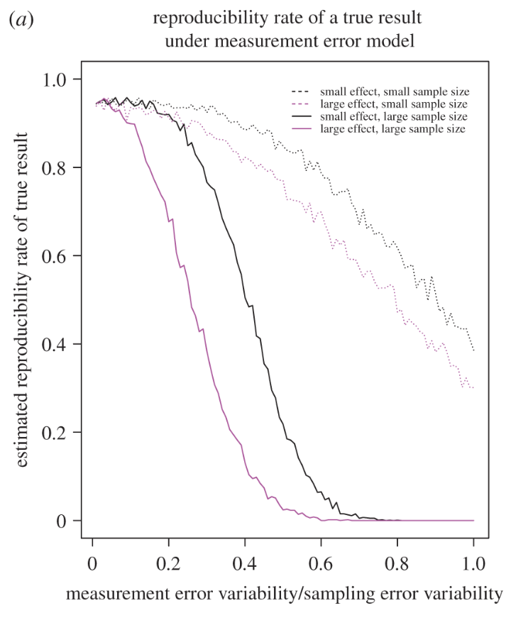

Devezer et al. (2021): Reproducibility rate of a true result decreases with measurement error in a misspecified simple linear regression model

## Preregistration of study plans is commonly recommended

- Reform movement advocates assert that in hypothesis testing
  - the analysis plan needs to be determined in advance:
  - *preregistered* before data collection
  - for statistical inference to be valid (e.g., Nosek et al., 2018)
- Doing so (supposedly) means we can
  - Close down the space for forking paths
  - Eliminate the potential for hypothesizing after results are known (*HARKing*)

## What *could* preregistration achieve?

- Whether we specify expectations before or after data are collected does not determine the validity of statistical tests (Devezer et al., 2021)
  - The validity of statistical procedures depends on the satisfaction of their assumptions *whatever they may be*
  - Nothing prevents a researcher from preregistering a poor analytical plan (Devezer et al., 2021)
- Researcher flexibility about analysis decision-making is more productively constrained by better defined theoretical requirements (Auspurg & Brüderl, 2021; Proulx & Morey, 2021; Smaldino, 2019; Szollosi et al., 2020)

## It is unclear what preregistration *actually* achieves

- Self-reported experiences of researchers who engage with preregistration are net positive (Sarafoglou et al., 2022) but
  - Researchers often deviate from preregistrations (Claesen et al., 2021), possibly rightly (Devezer et al., 2021)
  - Editors and reviewers do not appear to engage with preregistrations regularly (Syed, 2025)
  - Preregistration adds to research costs, most heavily for early career researchers (McDermott, 2022)
  - Preregistration restricts creativity (McDermott, 2022)

## Preregistration can be helpful

Hullman (2023): Preregistration can be helpful but our expectations about its utility should be modest:

- Developing a preregistered study or analysis plan enables researchers to think through the study design, data collection procedure and analysis in ways that are helpful

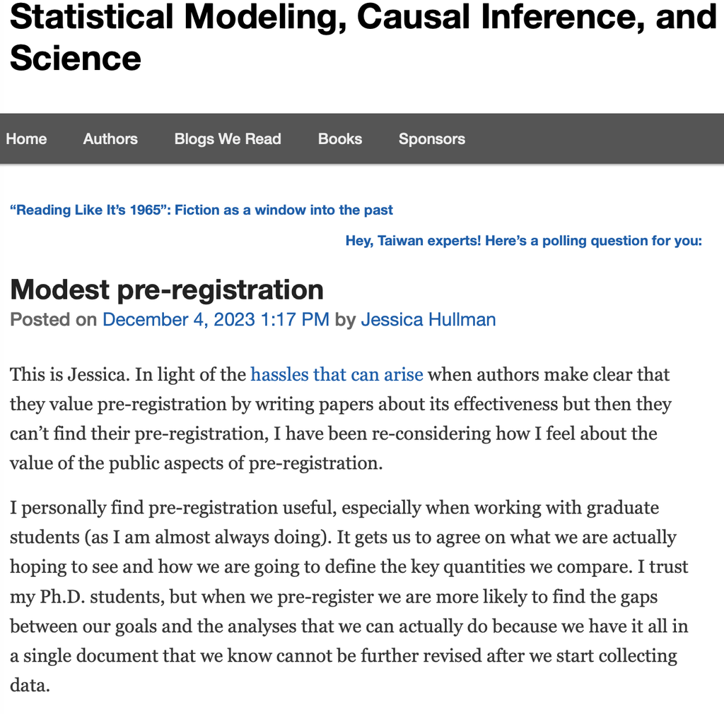

Hullman (2023)

## Preregistration can be helpful

Hullman (2023):

- Thinking in-depth in advance about measurement, sampling and modeling requirements is surely useful
- Explicit specific statements about your plans ensures that everyone in you team can understand and agree to actions

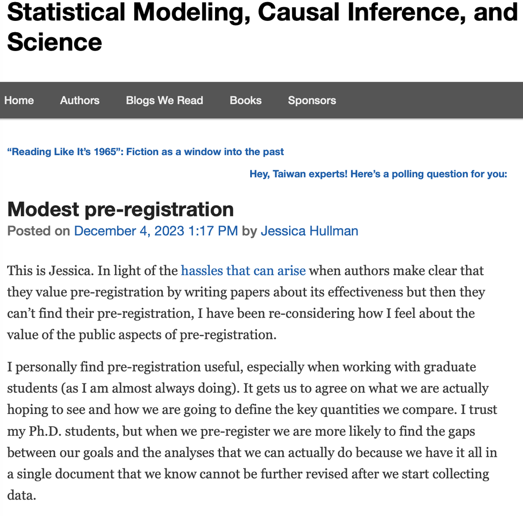

Hullman (2023)

## Data and code are more open

- Towse et al. (2021): There is increasing recognition that data archiving and public data-sharing can enhance research credibility and integrity
  - Results can be checked and validated by others
  - Data can be aggregated or re-analysed

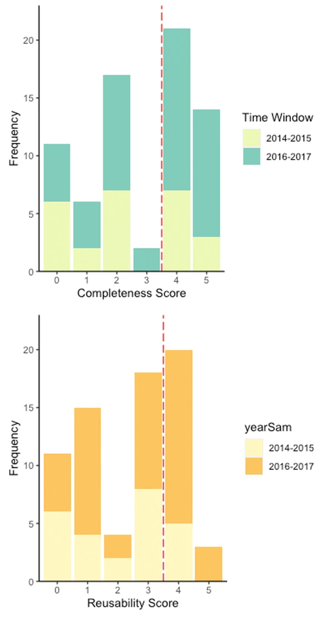

Towse et al. (2021): Shared but not FAIR

## But there are limitations in what is shared

Towse et al. (2021): are shared data Findable Accessible Interoperable and Reusable (FAIR, Wilkinson et al., 2016)?

- Data sharing has grown over time but varies between journals
  - Many of the examined datasets were incomplete
  - Archiving practices limit reusability:
    - Weaknesses in relation to provision of metadata
    - Incomplete documentation of data processing

## Automated checking could be useful

- Reform advocates suggest we use automated checks of accuracy in statistical reports (Vazire & Holcombe, 2022)
  - Nuijten et al. (2016) used `{statcheck}` to assess reports of significance tests on consistency of information about p-values, test statistics, and degrees of freedom
    - Half of all the published psychology papers that they analysed (8273/16695)
    - Contained at least one p-value that was inconsistent with its test statistic and degrees of freedom
  - Nuijten & Wicherts (2024): reporting inconsistencies were less prevalent in journals after adoption of `{statcheck}`

## What kinds of robustness are we looking for?

- The drive towards automated checks raised questions about the kinds of work that such checks will favour (Hullman, 2026a, 2026b), maybe:
  - Issues that humans missed will be found by automated checks
  - Workflows will come to build in robustness checks
    - But we will get selection for certain kinds of robustness and certain kinds of “safe” work

## Legible but narrow?

- Given the widespread adoption of automated checks, some kinds of work are bound to be advantaged
  - Because their features are “legible” (Scott, 1998)
  - Though there are no unproblematic signals of credibility (Hullman, 2026a, 2026b)

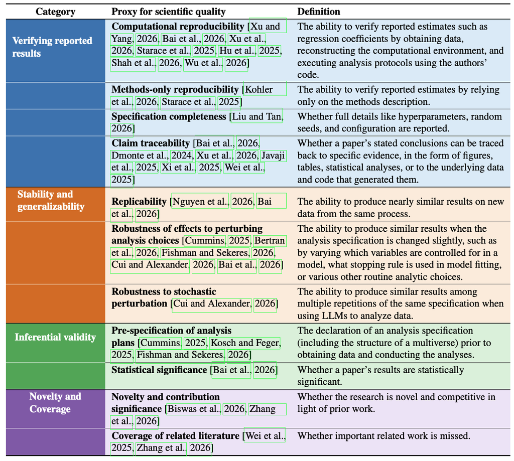

Hullman (2026a): kinds of robustness

## Legible but narrow?

- We should expect that whatever proxies we implement
- to structure attention in automated review
- will reshape science (Hullman, 2026a)

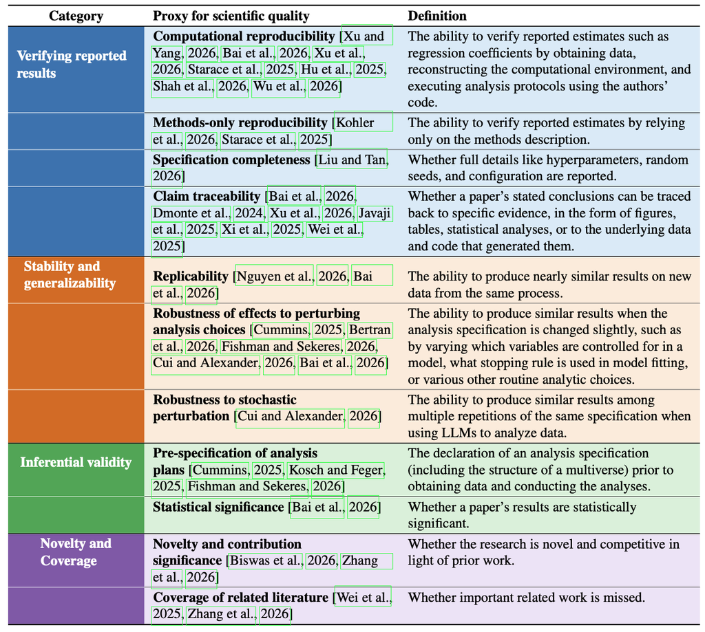

Hullman (2026a): kinds of robustness

## Activate

Our learning questions then are these:

**Activate**

- What kinds of work are favoured by reformist ideas about credibility?
  - What kinds of work are excluded?
- What kinds of things can automatic checks check?
  - What complexities or nuances will get missed or filtered out?
- How will we game credibility or rigour signalling in our work?

## Homophily, diversity and the natural selection of bad science

**The reasons**

- We will look at a persistent problem in psychological science:
  - low power analyses
- We will consider accounts of why this problem persists
- To examine how we can get to better science

## Thinking about power is rooted in Neyman and Pearson’s account of hypothesis testing

In hypothesis testing, we balance the risks of making different kinds of errors:

1. **False rejection of the null** hypothesis, *if null hypothesis is correct*
   - **Type 1** errors, also known as false positives
2. **False acceptance of the null** hypothesis, *if alternative hypothesis is correct*
   - **Type 2** errors, also known as false negatives

## A balance of error rates

In hypothesis testing, we balance the risks of making different kinds of errors:

1. We can assume: some chance that we will make a Type 1 error
- The probability of making a Type 1 error is $\alpha$ (“alpha”)
2. We can assume: some chance that we will make a Type 2 error
- The probability of making a Type 2 error is $\beta$ (“beta”)

## The Neyman-Pearson approach raises the question of power

- If $H_0$ is accepted and $H_A$ is rejected
  - though the alternative hypothesis is true
  - this is a Type 2 error
- We can balance the risk of Type 2 errors (the $\beta$ error rate) by planning for the **power** of our test

**Tip**

The power of a test is the long-run frequency of accepting $H_A$ the alternative hypothesis, if the alternative hypothesis is true

## The problem is that most reported analyses are low in power

- Low power in analyses have persisted (Maxwell, 2004; Sedlmeier & Gigerenzer, 1989; Vankov et al., 2014) ever since someone started looking (Cohen, 1962)
- Low power analyses are widespread in the social and biomedical sciences (Arel-Bundock et al., 2025; Button et al., 2013; Dumas-Mallet et al., 2017; Smaldino & McElreath, 2016; van Zwet et al., 2023)

## How low?

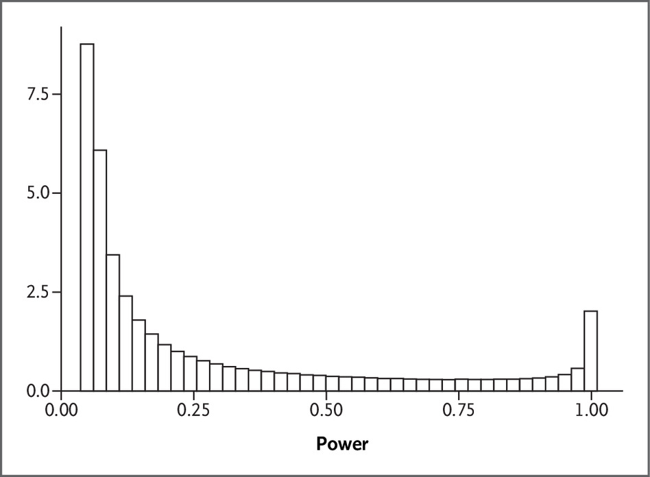

van Zwet et al. (2023): An examination of the results of 23,551 randomized clinical trials from the Cochrane Database of Systematic Reviews indicates that median power across the database for the true effect is only 13%

## How persistent?

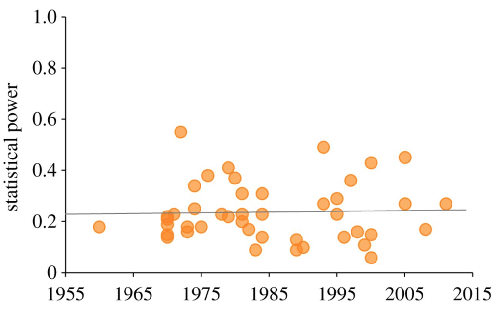

Smaldino & McElreath (2016): Average statistical power from 44 reviews of papers published in journals in the social and behavioural sciences between 1960 and 2011: very low power (mean=0.24) that has not increased over time

## Lack of power has consequences

- Lack of power will yield significant results but estimates that are inconsistent or unstable between studies (Bakker et al., 2012; Marek et al., 2022; Schönbrodt & Perugini, 2013)

## Lack of power has consequences

- If reports of low-power estimates are filtered for significance before publication
  - estimates will tend to be exaggerated
- because only biased-large estimates will *by chance* be significant given small samples (Bakker et al., 2012; Gelman & Carlin, 2014; van Zwet et al., 2023; Vasishth et al., 2018)

## What is going on? Natural selection of practices

- Nobody has to want to do bad science for population pressures to select for it (Smaldino & McElreath, 2016)
  - If science is a cultural activity
    - If its features can vary: methods can differ
    - If features are heritable: researchers can follow supervisors, teachers or examples
    - If variation in features has consequences for survival
  - Then evolutionary pressures can shape the population of scientists

## Natural selection of bad science

- Smaldino & McElreath (2016) report agent-based simulations of population dynamics
  - In these simulations, no-one cheats, no-one responds directly to incentives and everyone has utmost integrity
  - But research methods vary
    - Variation in methods have consequences for successful publication
    - Variation in success of publication has consequences for who gets hired or retained
    - Population dynamics takes care of the rest

## Natural selection of bad science

- Success in this system can depend on the number of positive results
  - Positive results are more likely to be published
  - More publications correspond to higher levels of fitness
  - Higher levels of fitness result in higher levels of reproductive success

## Natural selection of bad science

- You can get positive results by exerting effort to develop theory and build high power studies
- *Or* you can get positive results by acting in ways to increase the rate of false positives
  - Smaller studies cheaper to run but have low power
    - Low power is associated with a higher rate of false negatives
    - Low power is *also* associated with a higher rate of false positives: unstable or inconsistent estimates (Bakker et al., 2012; Marek et al., 2022; Schönbrodt & Perugini, 2013)

## Natural selection of bad science

- In a model in which researchers compete for prestige and jobs
  - the currency of fitness is number of publications
  - positive results are easier to publish than negative results
  - more successful labs have more progeny that inherit their method
- Selection can be found to favour labs who put in less effort towards ensuring quality work, increasing publication rates at the cost of more false discoveries

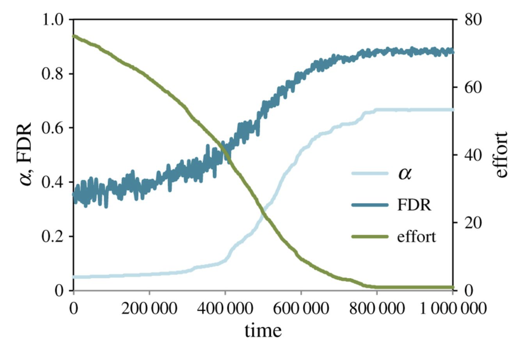

Smaldino & McElreath (2016): The evolution of low mean effort corresponds to evolution of high false-positive and false discovery rates

## How could these trends be mitigated?

- Smaldino & McElreath (2016): false discoveries and ambiguous results are inevitable with even the most rigorous methods
  - Though we have seen that the utility function of replications is complex (Devezer et al., 2021), direct and conceptual replications provide an approach to better understanding our observations (Hüffmeier et al., 2016; Lykken, 1968; Schmidt, 2009)
- But unless all published studies are replicated several times, some labs will avoid being caught
  - What about peer review?

## Homophily

- Why or how will bad practices persist?
  - Homophily (Akerlof & Michaillat, 2018): if tenured scientists favour candidates who adhere to their paradigm
    - Homophilous bias: People favor others from the same school of thought at every level of academic evaluation
    - Denying positions to practitioners of bad science is less likely if homophily is in play
    - Once a worse paradigm has many adherents it can prevail over alternatives

## Escaping the homophily trap

- How can we get out of this? We can:
  - Favour diversity (Akerlof & Michaillat, 2018; Graves et al., 2022; Kozlowski et al., 2022; Zumel Dumlao & Teplitskiy, 2025)
  - Promote interdisciplinarity (Smaldino & O’Connor, 2022)

## Interdisciplinarity can aid the spread of better methods

- Self-preferential bias (homophily, Akerlof & Michaillat, 2018) can protect poor methodology within scientific communities
- Lack of reviewer competence can contribute to failures to adopt better methods

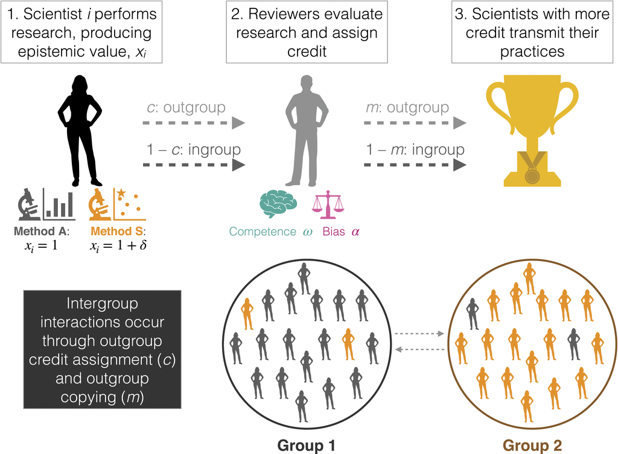

Smaldino & O’Connor (2022): Interdisciplinarity can aid the spread of better methods between scientific communities

## Interdisciplinarity can aid the spread of better methods

- But contact between disciplines can improve the chances that superior methods take over (Smaldino & O’Connor, 2022):
  - When reviewers from disciplines with different competences and biases are able to evaluate work within a problematic discipline
  - When individuals using poor methods occasionally copy the methods of (or collaborate with) successful peers in other fields

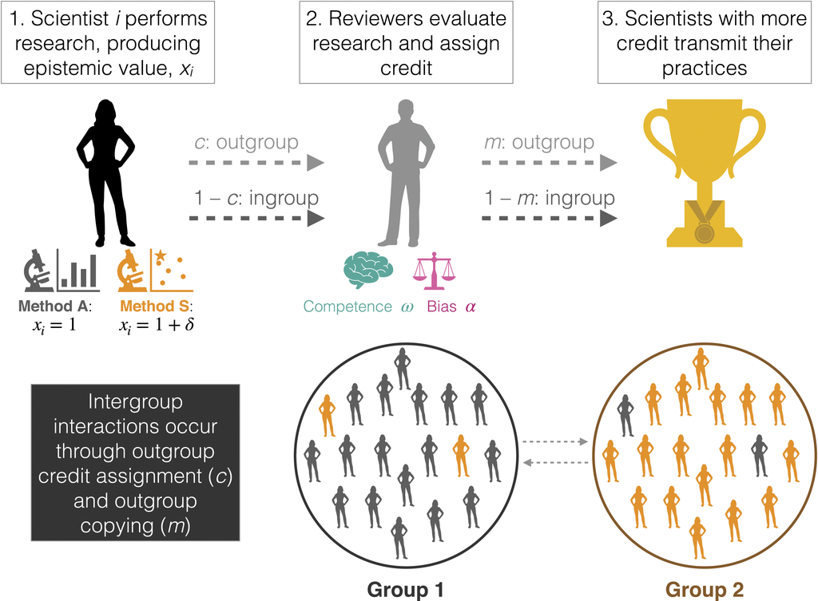

Smaldino & O’Connor (2022): Interdisciplinarity can aid the spread of better methods between scientific communities